# SodiumVsEthnicity

# 1 Reading the parquet file

```r
getwd()
```

```
## [1] "/Users/akashreddyashanna/Desktop/Fall 2025/Intro to DS/DataScienceProject"
```

```r
food <- read_parquet("proc_data/demo_foods.parquet")
```

# 2 Preprocessing

## 2.1 Describe Demographics

```r
## Categorical Variables
tbl <- food %>%
  select(RIAGENDR, RIDRETH3, DMDEDUC2, DMDMARTZ) %>%
  tbl_summary(
    type = list(
      RIAGENDR ~ "categorical",
      RIDRETH3 ~ "categorical",
      DMDEDUC2 ~ "categorical",
      DMDMARTZ ~ "categorical"
    ),
    statistic = all_continuous() ~ "{mean} ({sd})",
    missing = "ifany"   # <--- shows N (and %) of missing values
  ) %>%
  bold_labels()
tbl
```

| **Characteristic** | **N = 4,760**<sup>1</sup> |
| --- | --- |
| Gender |  |
| 1 | 2,114 (44%) |
| 2 | 2,646 (56%) |
| Race/Hispanic origin w/ NH Asian |  |
| 1 | 302 (6.3%) |
| 2 | 465 (9.8%) |
| 3 | 2,951 (62%) |
| 4 | 546 (11%) |
| 6 | 199 (4.2%) |
| 7 | 297 (6.2%) |
| Education level - Adults 20+ |  |
| 1 | 187 (3.9%) |
| 2 | 340 (7.1%) |
| 3 | 947 (20%) |
| 4 | 1,453 (31%) |
| 5 | 1,833 (39%) |
| Marital status |  |
| 1 | 2,597 (55%) |
| 2 | 1,237 (26%) |
| 3 | 924 (19%) |
| 99 | 2 (<0.1%) |

<sup>1</sup> n (%)

```r
tbl_df <- as_tibble(tbl, col_labels = TRUE)
write.xlsx(tbl_df, "output/EDA_categorical_demo.xlsx")

## Continuous Variables
tbl2 <- food %>%
  select(RIDAGEYR, DMDHHSIZ, INDFMPIR) %>%
  summarise(across(
    everything(),
    list(
      mean  = ~ mean(.x, na.rm = TRUE),
      sd    = ~ sd(.x, na.rm = TRUE),
      min   = ~ min(.x, na.rm = TRUE),
      max   = ~ max(.x, na.rm = TRUE),
      n_na  = ~ sum(is.na(.x))
    ),
    .names = "{.col}__{.fn}"
  )) %>%
  pivot_longer(
    everything(),
    names_to = c("variable", "stat"),
    names_sep = "__",
    values_to = "value"
  ) %>%
  pivot_wider(
    names_from = stat,
    values_from = value
  ) %>%
  mutate(label = sapply(variable, function(v) var_label(food[[v]]) %||% NA_character_)) %>%
  relocate(variable, label) %>%
  mutate(across(c(mean, sd, min, max), ~ round(.x, 2)))
tbl2
```

```
## # A tibble: 3 × 7
##   variable label                                    mean    sd   min   max  n_na
##   <chr>    <chr>                                   <dbl> <dbl> <dbl> <dbl> <dbl>
## 1 RIDAGEYR Age in years at screening               55.2  16.8     20    80     0
## 2 DMDHHSIZ Total number of people in the Household  2.47  1.39     1     7     0
## 3 INDFMPIR Ratio of family income to poverty        3.01  1.65     0     5   551
```

```r
write.xlsx(tbl2, "output/EDA_demogcontinuous_summary.xlsx")
```

## 2.2 Describe Food Nutrients

```r
food_labeled <- food %>%
  rename(
    "Calories (kcal)"      = DR1IKCAL_sum,
    "Protein (g)"          = DR1IPROT_sum,
    "Carbohydrates (g)"    = DR1ICARB_sum,
    "Sugars (g)"           = DR1ISUGR_sum,
    "Fiber (g)"            = DR1IFIBE_sum,
    "Total Fat (g)"        = DR1ITFAT_sum,
    "Sodium (mg)"          = DR1ISODI_sum
  )

foodsum<-xkablesummary(food_labeled[c(
  "Calories (kcal)",
  "Protein (g)",
  "Carbohydrates (g)",
  "Sugars (g)",
  "Fiber (g)",
  "Total Fat (g)",
  "Sodium (mg)"
)])
foodsum
```

Table: Statistics summary.

|  | Calories (kcal) | Protein (g) | Carbohydrates (g) | Sugars (g) | Fiber (g) | Total Fat (g) | Sodium (mg) |
| --- | --- | --- | --- | --- | --- | --- | --- |
| Min | Min. : 0 | Min. : 0 | Min. : 0 | Min. : 0 | Min. : 0.0 | Min. : 0 | Min. : 1 |
| Q1 | 1st Qu.: 1376 | 1st Qu.: 49 | 1st Qu.: 146 | 1st Qu.: 50 | 1st Qu.: 9.2 | 1st Qu.: 52 | 1st Qu.: 1986 |
| Median | Median : 1847 | Median : 67 | Median : 205 | Median : 81 | Median : 14.1 | Median : 76 | Median : 2770 |
| Mean | Mean : 1979 | Mean : 74 | Mean : 223 | Mean : 96 | Mean : 16.2 | Mean : 84 | Mean : 3068 |
| Q3 | 3rd Qu.: 2438 | 3rd Qu.: 92 | 3rd Qu.: 277 | 3rd Qu.:123 | 3rd Qu.: 20.7 | 3rd Qu.:106 | 3rd Qu.: 3802 |
| Max | Max. :10446 | Max. :459 | Max. :1301 | Max. :954 | Max. :127.3 | Max. :506 | Max. :20006 |

```r
#Making sure ethnic group is a factor with readable labels

food$RIDRETH3 <- factor(food$RIDRETH3,
                        levels = c(1, 2, 3, 4, 6, 7),
                        labels = c("Mexican American",
                                   "Other Hispanic",
                                   "Non-Hispanic White",
                                   "Non-Hispanic Black",
                                   "Non-Hispanic Asian",
                                   "Other Race - Including Multi-Racial"))
```

**Summary Statistics**

```r
sodium_summary <- food %>%
  group_by(RIDRETH3) %>%
  summarise(
    mean_sodium = mean(DR1ISODI_sum, na.rm = TRUE),
    sd_sodium   = sd(DR1ISODI_sum, na.rm = TRUE),
    median_sodium = median(DR1ISODI_sum, na.rm = TRUE),
    Sample_Size = n()
  )
xkabledply(sodium_summary, title = "Summary Statistics: Sodium Intake by Ethnic Groups")
```

Summary Statistics: Sodium Intake by Ethnic Groups

| RIDRETH3 | mean_sodium | sd_sodium | median_sodium | Sample_Size |
| --- | --- | --- | --- | --- |
| Mexican American | 3037 | 1574 | 2750 | 302 |
| Other Hispanic | 2776 | 1685 | 2487 | 465 |
| Non-Hispanic White | 3104 | 1568 | 2829 | 2951 |
| Non-Hispanic Black | 2969 | 1816 | 2539 | 546 |
| Non-Hispanic Asian | 3479 | 1724 | 3185 | 199 |
| Other Race - Including Multi-Racial | 3109 | 1588 | 2884 | 297 |

**We can see the mean, standard deviation , median and sample size for each group. From these numbers, we notice that Non-Hispanic Asians tend to have a higher mean sodium intake compared to other groups.** **This summary statistics give us an initial sense that there may be real differences between groups, but to confirm that, we’ll need visualize the data and later test statistically.**

# 3 Exploratory Data Analysis

## 3.1 SODIUM

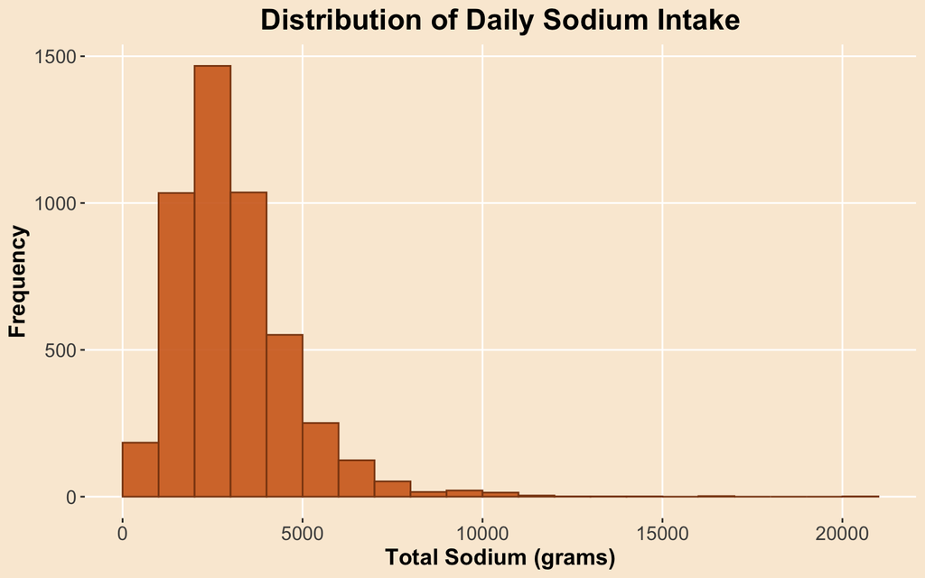

```r
hsodium <- ggplot(food, aes(DR1ISODI_sum)) +
  geom_histogram(
    breaks=seq(0, 21000, by = 1000),
    fill = "chocolate",
    color = "chocolate4",
    alpha = 0.9
  ) +
  labs(
    title = "Distribution of Daily Sodium Intake",
    x = "Total Sodium (grams)",
    y = "Frequency"
  ) +
  theme(
    # Background colors
    plot.background = element_rect(fill = "antiquewhite", color = NA),   # outside area
    panel.background = element_rect(fill = "antiquewhite", color = NA),  # plot area
    panel.grid.major = element_line(color = "white"),             # optional: lighten grid
    panel.grid.minor = element_blank(),

    # Font sizes
    plot.title = element_text(size = 18, face = "bold", hjust = 0.5),  # title
    axis.title = element_text(size = 14, face = "bold"),               # axis titles
    axis.text = element_text(size = 12)                                # axis labels
  )

# Display the plot
hsodium
```

```r
#Save th plot
ggsave("output/EDA_hist_sodium.png", plot = hsodium, width = 8, height = 6, dpi = 300)
```

**Sodium intake is heavily right-skewed which shows that most people consume moderate amounts, but there are few extreme outliers with very high intakes.**

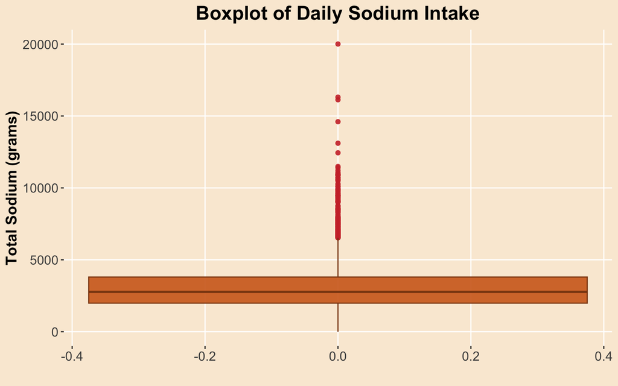

```r
bsodium <- ggplot(food, aes(y = DR1ISODI_sum)) +
  geom_boxplot(
    fill = "chocolate",
    color = "chocolate4",
    alpha = 0.9,
    outlier.color = "brown3",
    outlier.shape = 16,
    outlier.size = 2
  ) +
  labs(
    title = "Boxplot of Daily Sodium Intake",
    x = "",
    y = "Total Sodium (grams)"
  ) +
  theme(
    # Background colors
    plot.background = element_rect(fill = "antiquewhite", color = NA),
    panel.background = element_rect(fill = "antiquewhite", color = NA),
    panel.grid.major = element_line(color = "white"),
    panel.grid.minor = element_blank(),

    # Font sizes
    plot.title = element_text(size = 18, face = "bold", hjust = 0.5),
    axis.title = element_text(size = 14, face = "bold"),
    axis.text = element_text(size = 12)
  )

#Display the plot
bsodium
```

```r
# Save the boxplot
ggsave("output/EDA_box_sodium.png", plot = bsodium, width = 8, height = 6, dpi = 300)
```

**The boxplot clearly shows those outliers stretching far above the upper whisker.**

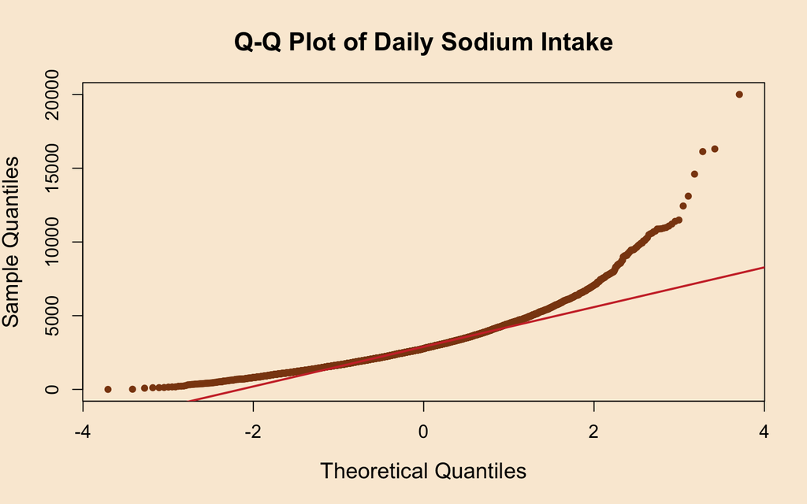

```r
par(
  bg = "antiquewhite",   # background color
  col.axis = "black",    # axis color
  col.lab = "black",     # label color
  col.main = "black",    # title color
  font.main = 2,         # bold title
  cex.main = 1.5,        # title size
  cex.lab = 1.3,         # axis title size
  cex.axis = 1.1         # axis label size
)

# Q-Q plot for Sodium Intake
qqnorm(
  food$DR1ISODI_sum,
  main = "Q-Q Plot of Daily Sodium Intake",
  pch = 19,               # filled points
  col = "chocolate4",     # point color
  cex = 0.8               # point size
)
qqline(
  food$DR1ISODI_sum,
  col = "brown3",         # line color
  lwd = 2                 # line thickness
)
```

```r
#Save the plot
dev.copy(png, "output/EDA_qq_sodium_base.png", width = 8, height = 6, units = "in", res = 300)
```

```r
dev.off()
```

**The Q–Q plot confirms the distribution deviates strongly from normality, especially in the upper tail.**

**This shows that sodium intake varies widely, with some individuals consuming exceptionally high levels.**

## 3.2 SODIUM-ETHNICITY

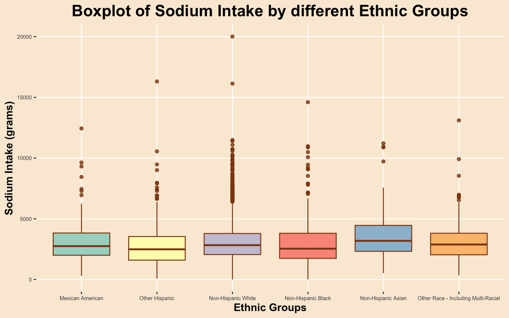

```r
box_sodium_ethnic <- ggplot(food, aes(x = RIDRETH3, y = DR1ISODI_sum, fill = RIDRETH3)) +
  geom_boxplot(
    alpha = 0.8,
    color = "chocolate4"
    ) +
  scale_fill_brewer(
    palette = "Set3"
    ) +
  labs(
    title = "Boxplot of Sodium Intake by different Ethnic Groups",
    x = "Ethnic Groups",
    y = "Sodium Intake (grams)"
    ) +
  theme(
    # Background colors
    plot.background = element_rect(fill = "antiquewhite", color = NA),
    panel.background = element_rect(fill = "antiquewhite", color = NA),
    panel.grid.major = element_line(color = "white"),
    panel.grid.minor = element_blank(),

    #Font sizes
    plot.title = element_text(size = 18, face = "bold", hjust = 0.5),
    axis.title = element_text(size = 12, face = "bold"),
    axis.text  = element_text(size = 6),
    legend.position = "none"
  )
# Display the plot
box_sodium_ethnic
```

```r
# Save plot
ggsave("output/EDA_box_sodium_ethnic.png", plot = box_sodium_ethnic, width = 8, height = 6, dpi = 300)
```

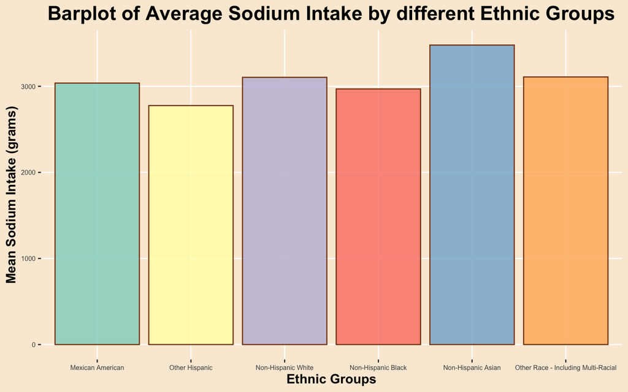

```r
bar_sodium_ethnic <- ggplot(sodium_summary, aes(x = RIDRETH3, y = mean_sodium, fill = RIDRETH3)) +
  geom_col(
    alpha = 0.8,
    color = "chocolate4"
    ) +
  scale_fill_brewer(
    palette = "Set3"
    ) +
  labs(
    title = "Barplot of Average Sodium Intake by different Ethnic Groups",
    x = "Ethnic Groups",
    y = "Mean Sodium Intake (grams)"
  ) +
  theme(
    # Background colors
    plot.background = element_rect(fill = "antiquewhite", color = NA),
    panel.background = element_rect(fill = "antiquewhite", color = NA),
    panel.grid.major = element_line(color = "white"),
    panel.grid.minor = element_blank(),

    # Font sizes
    plot.title = element_text(size = 18, face = "bold", hjust = 0.5),
    axis.title = element_text(size = 12, face = "bold"),
    axis.text  = element_text(size = 6),
    legend.position = "none"
  )

# Display the plot
bar_sodium_ethnic
```

```r
# Save plot
ggsave("output/EDA_bar_sodium_ethnic.png", plot = bar_sodium_ethnic, width = 8, height = 6, dpi = 300)
```

# 4 Hypothesis Testing - ANOVA Test

**Null Hypothesis (H0): There is no significant difference in mean sodium intake among ethnic groups.**

**Alternative Hypothesis (H1) : There is a significant difference in mean sodium intake among at least one ethnic groups.**

**Since we have one independent variable - ethnicity with multiple groups and one dependent variable - sodium intake the most suitable statistical method is a One-Way ANOVA.This test helps us determine whether the differences in mean sodium intake that we observed visually are statistically meaningful or just due to random chance.**

## 4.1 ANOVA Test

```r
anova_result <- aov(DR1ISODI_sum ~ RIDRETH3, data = food)
anova_result
```

```
## Call:
##    aov(formula = DR1ISODI_sum ~ RIDRETH3, data = food)
##
## Terms:
##                 RIDRETH3 Residuals
## Sum of Squares  8.32e+07  1.24e+10
## Deg. of Freedom        5      4754
##
## Residual standard error: 1618
## Estimated effects may be unbalanced
```

```r
xkabledply(anova_result, title = "ANOVA Summary: Sodium Intake by Ethnic Groups")
```

ANOVA Summary: Sodium Intake by Ethnic Groups

|  | Df | Sum Sq | Mean Sq | F value | Pr(>F) |
| --- | --- | --- | --- | --- | --- |
| RIDRETH3 | 5 | 8.32e+07 | 16645718 | 6.36 | 0 |
| Residuals | 4754 | 1.24e+10 | 2618734 | NA | NA |

**The results shows a significant p-value less than 0.05, which means we can reject the null hypothesis, indicating that there is indeed a statistically significant difference in sodium intake among at least one of the ethnic groups.** **To know which ethnic groups differ, we are using Post-hoc Tukey HSD.**

## 4.2 Post-hoc Tukey HSD Test

```r
tukeyAoV <- TukeyHSD(anova_result)
tukeyAoV
```

```
##   Tukey multiple comparisons of means
##     95% family-wise confidence level
##
## Fit: aov(formula = DR1ISODI_sum ~ RIDRETH3, data = food)
##
## $RIDRETH3
##                                                           diff    lwr    upr
## Other Hispanic-Mexican American                        -261.27 -602.2   79.7
## Non-Hispanic White-Mexican American                      66.98 -211.7  345.7
## Non-Hispanic Black-Mexican American                     -68.02 -398.9  262.8
## Non-Hispanic Asian-Mexican American                     441.67   20.4  862.9
## Other Race - Including Multi-Racial-Mexican American     71.32 -305.7  448.3
## Non-Hispanic White-Other Hispanic                       328.25   98.1  558.4
## Non-Hispanic Black-Other Hispanic                       193.24  -97.9  484.4
## Non-Hispanic Asian-Other Hispanic                       702.94  312.1 1093.7
## Other Race - Including Multi-Racial-Other Hispanic      332.58  -10.1  675.3
## Non-Hispanic Black-Non-Hispanic White                  -135.00 -349.9   79.9
## Non-Hispanic Asian-Non-Hispanic White                   374.69   36.8  712.6
## Other Race - Including Multi-Racial-Non-Hispanic White    4.33 -276.5  285.2
## Non-Hispanic Asian-Non-Hispanic Black                   509.69  127.7  891.7
## Other Race - Including Multi-Racial-Non-Hispanic Black  139.34 -193.3  472.0
## Other Race - Including Multi-Racial-Non-Hispanic Asian -370.35 -793.0   52.3
##                                                        p adj
## Other Hispanic-Mexican American                        0.245
## Non-Hispanic White-Mexican American                    0.984
## Non-Hispanic Black-Mexican American                    0.992
## Non-Hispanic Asian-Mexican American                    0.033
## Other Race - Including Multi-Racial-Mexican American   0.995
## Non-Hispanic White-Other Hispanic                      0.001
## Non-Hispanic Black-Other Hispanic                      0.407
## Non-Hispanic Asian-Other Hispanic                      0.000
## Other Race - Including Multi-Racial-Other Hispanic     0.063
## Non-Hispanic Black-Non-Hispanic White                  0.472
## Non-Hispanic Asian-Non-Hispanic White                  0.020
## Other Race - Including Multi-Racial-Non-Hispanic White 1.000
## Non-Hispanic Asian-Non-Hispanic Black                  0.002
## Other Race - Including Multi-Racial-Non-Hispanic Black 0.840
## Other Race - Including Multi-Racial-Non-Hispanic Asian 0.125
```

```r
# Renaming the column names
tukey_table <- tidy(tukeyAoV) %>%
  rename(
    Comparison = contrast,
    Mean_Difference = estimate,
    Lower_95CI = conf.low,
    Upper_95CI = conf.high,
    Adjusted_p = adj.p.value
  ) %>%
  mutate(Significance = ifelse(Adjusted_p < 0.05, "Significant", "Not Significant"))

# Print clean formatted table
kable(
  tukey_table,
  caption = "Tukey HSD Post-hoc Test for Sodium Intake Across Ethnic Groups",
  digits = 3,
  align = "lccccc"
)
```

Tukey HSD Post-hoc Test for Sodium Intake Across Ethnic Groups

| term | Comparison | null.value | Mean_Difference | Lower_95CI | Upper_95CI | Adjusted_p | Significance |
| --- | --- | --- | --- | --- | --- | --- | --- |
| RIDRETH3 | Other Hispanic-Mexican American | 0 | -261.26 | -602.2 | 79.7 | 0.245 | Not Significant |
| RIDRETH3 | Non-Hispanic White-Mexican American | 0 | 66.98 | -211.7 | 345.7 | 0.984 | Not Significant |
| RIDRETH3 | Non-Hispanic Black-Mexican American | 0 | -68.02 | -398.9 | 262.8 | 0.992 | Not Significant |
| RIDRETH3 | Non-Hispanic Asian-Mexican American | 0 | 441.67 | 20.4 | 862.9 | 0.033 | Significant |
| RIDRETH3 | Other Race - Including Multi-Racial-Mexican American | 0 | 71.32 | -305.7 | 448.3 | 0.995 | Not Significant |
| RIDRETH3 | Non-Hispanic White-Other Hispanic | 0 | 328.25 | 98.1 | 558.4 | 0.001 | Significant |
| RIDRETH3 | Non-Hispanic Black-Other Hispanic | 0 | 193.24 | -97.9 | 484.4 | 0.407 | Not Significant |
| RIDRETH3 | Non-Hispanic Asian-Other Hispanic | 0 | 702.94 | 312.1 | 1093.7 | 0.000 | Significant |
| RIDRETH3 | Other Race - Including Multi-Racial-Other Hispanic | 0 | 332.58 | -10.1 | 675.3 | 0.063 | Not Significant |
| RIDRETH3 | Non-Hispanic Black-Non-Hispanic White | 0 | -135.00 | -349.9 | 79.9 | 0.472 | Not Significant |
| RIDRETH3 | Non-Hispanic Asian-Non-Hispanic White | 0 | 374.69 | 36.8 | 712.6 | 0.020 | Significant |
| RIDRETH3 | Other Race - Including Multi-Racial-Non-Hispanic White | 0 | 4.33 | -276.5 | 285.2 | 1.000 | Not Significant |
| RIDRETH3 | Non-Hispanic Asian-Non-Hispanic Black | 0 | 509.69 | 127.7 | 891.7 | 0.002 | Significant |
| RIDRETH3 | Other Race - Including Multi-Racial-Non-Hispanic Black | 0 | 139.34 | -193.3 | 472.0 | 0.840 | Not Significant |
| RIDRETH3 | Other Race - Including Multi-Racial-Non-Hispanic Asian | 0 | -370.35 | -793.0 | 52.3 | 0.125 | Not Significant |

**From the Tukey HSD results, we can conclude that Non-Hispanic Asian (Asian Americans) adults have a significantly higher sodium intake compared to Mexican Americans, Other Hispanics, Non-Hispanic Whites, and Non-Hispanic Blacks.**

**This supports what we observed earlier in the boxplots and barplots. The findings are consistent with previous studies, which reported similar trends among the U.S. adults.**

**Overall, this analysis highlights that sodium intake does differ among ethnic groups, likely due to cultural dietary habits, traditional food patterns, and cooking practices. Understanding these differences can help inform more culturally tailored public health nutrition guidelines.**